# Coursework Report

*N* removed NAs: 2

*N* removed typo: 1

*N* removed <18: 21

*N* total clean: 126

| Group | *N* | *M*<sub>age</sub> | *M*<sub>rating</sub> |
| --- | --- | --- | --- |
| Control | 62 | 21.4 | 6.33 |
| Experim | 64 | 21.3 | 5.71 |

**Main analysis results**

*t*(124) = 4.11, *p* < .001

[interactive chart not shown]

[figure not shown]

[interactive chart not shown]

# Coursework Report

Analysing Data, Spring 2020

# Methods

## Participants

Table 1 *Descriptive statistics of age by condition.*

| Condition | n | Percentage | Mean Age | SD | Max Age | Min Age |
| --- | --- | --- | --- | --- | --- | --- |
| control | 62 | 49.2 | 21.4 | 2.28 | 27 | 18 |
| experimental | 64 | 50.8 | 21.3 | 1.78 | 27 | 18 |

## Design

The current study considers whether women perceive men as more attractive in conjunction with the colour red. The independent variable was the colour of the background of a black and white image of a man, either red (experimental) or white (control) which was shown to the participants for five seconds. The dependent variable was the participant’s rating of percieved attractiveness of the man. This was measured by asking the participants three questions: 1) “How attractive do you think this person is?” 2)“How pleasant is this person to look at?” 3)“If I were to meet the person in this picture face to face, I would think he is attractive.” Participants were asked to indicate their answers on a 9 point scale, with 1 being “not at all attractive” and 9 being “extremely attractive”, scores from all three questions were then averaged to form a composite score for data analysis. An independent-samples *t*-test was then used to examine whether showing the colour red in conjuction with an image of a man enhances women’s percived attractiveness of that man.

# Results

An independent *t* test was performed to compare the attractiveness ratings given to a photo of a man on either a white background (control group) or a red background (experimental group). The data used for the statistical test were composite scores made up from the answers of three different questions participants answered during the study using a rating scale of 1 to 9. There was a significant difference found in the composite ratings of the control group which had a mean of 6.33 and the experimental group which had a mean of 5.71, suggesting we are potentially able to reject the null hypothesis: (*M*<sub>diff</sub> = 0.62, 95% CI [0.32, 0.93], *t* (124) = 4.11, *p* = .0001). However, the results show a contradicting relationship to our hypothesis, consistent with the descriptive statistics which when inspected indicates that the control group rated the man as more attractive than the experiemental group. This suggests that the red background did not increase the female participants’ perception of the man’s attractiveness, consequentially leading us to reject our alternative hypothesis and accept the null.

Table 2 *Descriptive statistics of results by condition.*

| Condition | n | Mean Score | SD | Max Score | Min Score |
| --- | --- | --- | --- | --- | --- |
| control | 62 | 6.33 | 0.9 | 9 | 4.33 |
| experimental | 64 | 5.71 | 0.8 | 8 | 3.67 |

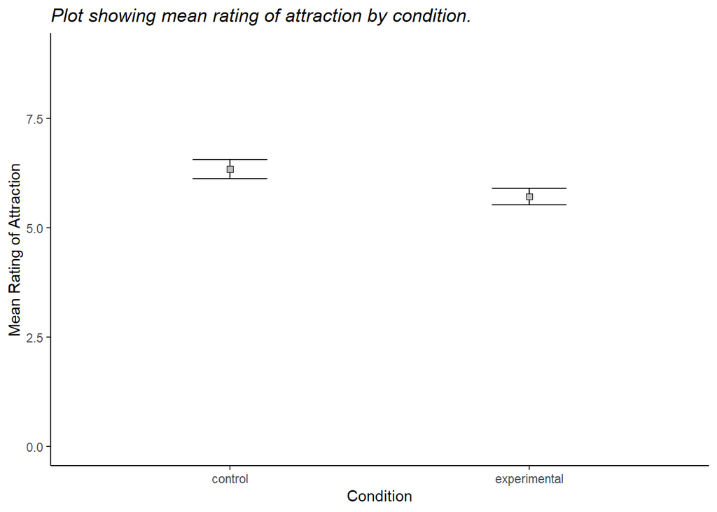

# Discussion

The current study investigated the effects of the colour red on women’s perception of male attractiveness and predicted that black and white images of a man on a red background would produce higher attractiveness ratings from female participants than the same image on a white background. Although there was a clear difference in mean data from both the control and experimental condition, the results contradicted the hypothesis and showed higher attractiveness ratings in the control condition with a mean rating of 6.33 than in the red condition with a mean rating of 5.71. These findings do not support those of the original Elliot et al (2010) study in which a positive relationship was found between the viewing of images with red backgrounds and higher ratings of attractiveness with the experimental group’s mean rating at 6.79 and the control group’s at 5.67. Elliot et al’s (2010) findings mirror other studies in this field, proving that this colour effect can be observed, therefore highlighting an importance to consider methodological approaches carefully when exploring this phenomenon.

The outcome of the current study suggests a sensitivity in the way in which the colour red is displayed in conjunction with the male who’s attractiveness is being rated, perhaps providing reason to consider using the background of an image as an independent variable a limitation in this study. For example, it could be argued that this way of displaying red is more likely to invoke associations with danger in participants than attraction, with Pravossoudovitch et al (2014) using similar methods of displaying red to their participants and finding significant links with the colour red and danger and therefore avoidance behaviours which could potentially explain lower attractiveness ratings in the experimental condition in the current study while supporting the idea that colours influence psychological processes. This limitation could be resolved in future research by adjusting the way red is displayed such as using a man’s clothing which was seen in Pazda & Elliot’s (2017) study that produced results supporting the red effect on attraction.

A notable strength of the current study is the use of multiple questions being asked to the participants and using a composite score in analysis in order to convey specificity in the definition of ‘attractiveness’ that could be considered as having different meanings between participants, such being sexual or platonic in nature. This approach has successfully produced significant results by researchers such as Sprecher & Regan (2002) and is important when studying the affect of the colour red on perceived male attractiveness as it avoids measuring other phenomena linked with the colour red such as passion or lust (Aslam, 2006) while also avoiding ideas of perceived higher status equating to higher attractiveness acting as confounding variables affecting the ratings of the participants.

The current study investigates whether viewing a man in conjunction with the colour red makes women perceive them as more attractive than a man presented without any format of red, using the colour in a static format. However Elliot et al (2010) note in their original study that it is important for future research to explore whether the red effect is generalisable when being viewed in a dynamic form. For example, it has been found that women are sensitive to detecting blood flow changes in the face (Changizi et al, 2006) which could be useful in researching whether a women’s perception of man’s attractiveness fluctuates in correlation to blood flow and therefore reddening of the face for dynamic rather than static research. This kind of research can further be viewed as favourable in exploring the red effect in the way that it takes advantage of naturally occurring phenomenon, giving rise to higher levels of ecological validity and making findings potentially generalisable to a wider population. This idea was also conveyed in criticisms of Peperkoorn et al’s (2016) study where clothing was used to display red in conjunction with males and results were obtained similar to the current study with no evidence for a colour effect being found. These criticisms noted that the red effect is often viewed as ‘primitive’ (Pazda and Elliot, 2017), suggesting the use of something naturally occurring like blushing red cheeks may be more appropriate in research of this topic.

Additionally, naturally occurring phenomena could be utilised in future research for measuring attraction in the female participants to avoid biases that can occur using self-report techniques. These methods can be seen in Clore & Gormly’s (1974) research in which attraction was associated with high bodily arousal and was explored using skin conductance and heart rate measures. Future research may also benefit from making use of recent discoveries about brain regions that are linked to romantic desire, such as the anterior cingulate cortex (Diamond et al, 2012), suggesting that neuroimaging techniques may be viable and reliable options for measuring attraction that has sometimes been noted to occur subconsciously and create innate responses when associated with the colour red (Pazda and Elliot, 2017).

In conclusion, the research question of whether women perceive men as more attractive in conjunction with the colour red remains a topic for further deliberation by psychologists and although the current study displays results in an unexpected direction, a significant effect of the colour red is able to be seen as displayed in other literature of this topic. This demonstrates the motivation for investigating how colour can influence an individual’s psychological processing and provides rationale for actionable suggestions of future research, such as making use of natural occurring phenomena like blushing to display the colour red and using innovative ways of operationalising perceived attractiveness, like heart rate or brain region activation, for example. Research in this area would supplement public interest and psychological knowledge alike by helping to broaden understanding of attraction itself and how friendships or romantic relationships can emerge.

# References

Aslam, M. M. (2006). Are you selling the right colour? A cross‐cultural review of colour as a marketing cue. *Journal of marketing communications, 12*(1), 15-30.

Changizi, M. A., Zhang, Q., & Shimojo, S. (2006). Bare skin, blood and the evolution of primate colour vision. *Biology letters, 2*(2), 217-221.

Clore, G. L., & Gormly, J. B. (1974). Knowing, feeling, and liking a psychophysiological study of attraction. *Journal of Research in Personality, 8*(3), 218-230.

Diamond, Lisa M., and Janna A. Dickenson. “The neuroimaging of love and desire: review and future directions.” *Clinical Neuropsychiatry 9*, no. 1 (2012).

Elliot, A. J., Niesta Kayser, D., Greitemeyer, T., Lichtenfeld, S., Gramzow, R. H., Maier, M. A., & Liu, H. (2010). Red, rank, and romance in women viewing men. *Journal of Experimental Psychology: General, 139*(3), 399.

Pazda, A. D., & Elliot, A. J. (2017). Processing the word red can enhance women’s perceptions of men’s attractiveness. *Current Psychology, 36*(2), 316-323.

Peperkoorn, L. S., Roberts, S. C., & Pollet, T. V. (2016). Revisiting the red effect on attractiveness and sexual receptivity: No effect of the color red on human mate preferences. *Evolutionary Psychology, 14*(4), 1474704916673841.

Pravossoudovitch, K., Cury, F., Young, S. G., & Elliot, A. J. (2014). Is red the colour of danger? Testing an implicit red–danger association. Ergonomics, 57(4), 503-510. Schwarz, S., & Singer, M. (2013). Romantic red revisited: Red enhances men’s attraction to young, but not menopausal women. *Journal of Experimental Social Psychology, 49*(1), 161-164.

Sprecher, S., & Regan, P. C. (2002). Liking some things (in some people) more than others: Partner preferences in romantic relationships and friendships. *Journal of Social and Personal Relationships, 19*(4), 463-481.